# EPIC Orientation 2019: Introduction to R

Updated: 12 August 2019

## Overview

1. Importing data
2. R Data Types
3. Working with dataframes
4. Data Manipulation with dplyr
5. Reshaping data with tidyr
6. Vectorized functions
7. Data Visualization using ggplot2
8. Fitting Linear Models

## 1. Importing data

For starters, we will be working with `tv_hurricanes_by_network.csv`, which contains the percentage of TV news that mention Hurricanes Harvey, Irma, Jose, and Maria each day.

Source: https://github.com/fivethirtyeight/data/tree/master/puerto-rico-media

Let’s get started.

```r
#clean environment
rm(list = ls())

#to get current working directory
getwd()
```

```
## [1] "C:/Users/Claire Fan/orientation2019/R"
```

```r
#to get help for a function
#Method 1:
help("read.csv")
```

```
## starting httpd help server ... done
```

```r
#Method 2:
?"read.csv"

#import csv
df <- read.csv("datasets/tv_hurricanes_by_network.csv")
```

R also has the capability to import other file formats including Stata, SPSS, SAS and Excel files using functions such as `read.spss()`, `read.dta()`, and `read.xport()`. You may wish to explore the `foreign` package to find out more.

## 2. R Data Types

You will encounter a variety of data structures in R:

#### vector

- - a one-dimensional array
  - elements of a vector must be of the same type
  - `numeric_vector <- c(0.1, 2, 4.678)`
  - `character <- c("EPIC", "is", "epic!")`
  - `logical <- c(T, F, T, T)`
  - factor: categorical variable with predefined set of possible values (“levels”) and, optionally, a rank order. Looks like character strings, but internally, the levels are mapped to integers

#### matrix

- - 2-D vector
  - all columns in a matrix must be of the same type (numeric, character, etc.) and the same length

#### dataframe

- - more general than a matrix, different columns can have different types (numeric, character, factor, etc.)

#### list

- - an ordered collection of objects (components), a list allows you to gather (possibly unrelated) objects under one name (e.g. a string, a numeric vector, a matrix, and a scalar) e.g. `mylist <- list("Hello", c(1,2,5.3,6,-2,4), matrix(1:20, nrow=5,ncol=4), 9)`
  - you can also make lists of lists e.g. `mylist <- list(list1, list2, list3)`

Let’s examine our data.

```r
#see structure of object
str(df)
```

```
## 'data.frame':    84 obs. of  6 variables:
##  $ Date    : Factor w/ 33 levels "8/24/17","8/25/17",..: 17 18 19 21 22 23 24 25 26 8 ...
##  $ Query   : Factor w/ 4 levels "Hurricane Harvey",..: 4 4 4 4 4 4 4 4 4 2 ...
##  $ BBC.News: num  0 0.22 0.89 0.988 0.476 ...
##  $ CNN     : num  0.029 0.187 0.582 0.798 0.645 ...
##  $ FOX.News: num  0.0079 0.1877 0.1779 0.5387 0.3177 ...
##  $ MSNBC   : num  0.0208 0.0473 0.2621 0.4835 0.2406 ...
```

```r
#see class of a variable
class(df$Query)
```

```
## [1] "factor"
```

R is currently treating the Query variable as nominal, let’s change it to a character type.

```r
#change Query variable to a character type
df$Query <- as.character(df$Query)
#see structure
str(df)
```

```
## 'data.frame':    84 obs. of  6 variables:
##  $ Date    : Factor w/ 33 levels "8/24/17","8/25/17",..: 17 18 19 21 22 23 24 25 26 8 ...
##  $ Query   : chr  "Hurricane Maria" "Hurricane Maria" "Hurricane Maria" "Hurricane Maria" ...
##  $ BBC.News: num  0 0.22 0.89 0.988 0.476 ...
##  $ CNN     : num  0.029 0.187 0.582 0.798 0.645 ...
##  $ FOX.News: num  0.0079 0.1877 0.1779 0.5387 0.3177 ...
##  $ MSNBC   : num  0.0208 0.0473 0.2621 0.4835 0.2406 ...
```

## 3. Working with Dataframes

Sometimes we deal with large dataframes and we don’t always get the luxury of viewing it in its entirety. Instead, we can use the following functions:

```r
#see dimensions (in this order: row, column)
dim(df)
```

```
## [1] 84  6
```

```r
#view the first 2 obs
head(df, 2)
```

```
##      Date           Query BBC.News    CNN FOX.News  MSNBC
## 1 9/17/17 Hurricane Maria   0.0000 0.0290   0.0079 0.0208
## 2 9/18/17 Hurricane Maria   0.2204 0.1866   0.1877 0.0473
```

```r
#view the last 3 obs
tail(df, 3)
```

```
##       Date          Query BBC.News    CNN FOX.News  MSNBC
## 82 9/19/17 Hurricane Jose        0 0.0000   0.0148 0.0638
## 83 9/20/17 Hurricane Jose        0 0.0000   0.0146 0.0000
## 84 9/21/17 Hurricane Jose        0 0.0084   0.0069 0.0000
```

```r
#summary statistics
summary(df)
```

```
##       Date       Query              BBC.News            CNN
##  9/17/17: 4   Length:84          Min.   :0.00000   Min.   :0.00000
##  9/18/17: 4   Class :character   1st Qu.:0.00000   1st Qu.:0.01022
##  9/19/17: 4   Mode  :character   Median :0.02575   Median :0.10995
##  9/20/17: 4                      Mean   :0.20525   Mean   :0.20312
##  9/21/17: 4                      3rd Qu.:0.21240   3rd Qu.:0.25377
##  9/10/17: 3                      Max.   :1.46330   Max.   :1.11460
##  (Other):61
##     FOX.News           MSNBC
##  Min.   :0.00000   Min.   :0.0000
##  1st Qu.:0.02815   1st Qu.:0.0146
##  Median :0.09405   Median :0.0444
##  Mean   :0.19866   Mean   :0.1568
##  3rd Qu.:0.23650   3rd Qu.:0.2070
##  Max.   :1.20800   Max.   :1.2863
##
```

To access specific columns or rows by name or index:

```r
#Get the 2nd observation of the Query Variable
df[2, 'Query'] #Method 1
```

```
## [1] "Hurricane Maria"
```

```r
df$Query[2] #Method 2
```

```
## [1] "Hurricane Maria"
```

```r
#Get the 3rd observation of the 5th variable
df[3,5]
```

```
## [1] 0.1779
```

```r
#Grab multiple elements (from the 1st & 2nd rows, 4th & 5th columns)
df[c(1,2), c(4,5)]
```

```
##      CNN FOX.News
## 1 0.0290   0.0079
## 2 0.1866   0.1877
```

You can also perform functions or use operators on vectors

```r
#Find the minimum value of CNN
min(df$CNN)
```

```
## [1] 0
```

```r
#Sum of all obs in BBC.News
sum(df$BBC.News)
```

```
## [1] 17.2409
```

```r
#Standard deviation of Fox News
sd(df$FOX.News)
```

```
## [1] 0.2652226
```

```r
#Multiple CNN by 2
df$CNN.times.2 <- df$CNN*2
#Remove this newly created column
df$CNN.times.2 <- NULL
#Add variables together
df$CNN.plus.BBC <- df$CNN + df$BBC.News
#Convert Date variable from Factor to Date format
df$Date <- as.Date(df$Date, format = "%m/%d/%y")
#Tabulate the Query variable, how many observations are Hurricane Irma?
table(df$Query)
```

```
##
## Hurricane Harvey   Hurricane Irma   Hurricane Jose  Hurricane Maria
##               33               26               16                9
```

There are several ways to rename a column. For instance, if we’d like to rename the “Query”" column to “Hurricane”

```r
#view all variable names in df
names(df)
```

```
## [1] "Date"         "Query"        "BBC.News"     "CNN"
## [5] "FOX.News"     "MSNBC"        "CNN.plus.BBC"
```

```r
#Method 1: rename the second variable, aka Query
names(df)[2] <- "HURRICANE" #Method 1
#Method 2: rename based on the name
names(df)[names(df)=="HURRICANE"] <- "Hurricane"
#view all variable names in df again
names(df)
```

```
## [1] "Date"         "Hurricane"    "BBC.News"     "CNN"
## [5] "FOX.News"     "MSNBC"        "CNN.plus.BBC"
```

```r
#Method 3: use rename() from the dplyr package which we will cover later
```

### Quiz 1:

Create a numeric variable that assigns the following damage costs to each of the hurricanes. Name this variable `Costs` and use millions as the unit.

- Harvey: $125Bn
- Maria: $90Bn
- Irma: $64.8Bn
- Jose: $2.8M

##### *âIf you look for it, I’ve got a sneaky feeling you’ll find that love actually is all around.â - Prime Minister David (Hugh Grant)*

```r
df$Costs[df$Hurricane=="Hurricane Harvey"] <- 125 * 1000
df$Costs[df$Hurricane=="Hurricane Irma"] <- 64.8 * 1000
df$Costs[df$Hurricane=="Hurricane Maria"] <- 90 * 1000
df$Costs[df$Hurricane=="Hurricane Jose"] <- 2.8
```

## 4. Data Manipulation with dplyr

#### What’s dplyr?

dplyr is a powerful package written by the amazing Hadley Wickham. It provides some easy-to-use functions for data analysis and manipulation.

```r
#install package
#install.packages("dplyr")
#load this package in your R environment
library(dplyr)
```

Now let’s try out some of the most commonly-used functions.

- `select()` - select specific columns
- `mutate()` - create a new column
- `rename()` - rename columns
- `filter()` - select rows using a criteria
- `arrange()` - arrange rows
- `group_by()` - group data
- `summarise()` - summarize values

`select()` allows you to select specific columns from your dataframe.

```r
#select just the Date and CNN columns and display the first 3 observations
#my R is buggy but you should be able to run just this: head(select(df, Date, CNN))
head(dplyr::select(df, Date, CNN), 3)
```

```
##         Date    CNN
## 1 2017-09-17 0.0290
## 2 2017-09-18 0.1866
## 3 2017-09-19 0.5818
```

`mutate()` allows you to create new variables

```r
#create a new column called BBC.and.CNN and display just the first 3 rows
head(mutate(df, BBC.and.CNN=BBC.News+CNN), 3)
```

```
##         Date       Hurricane BBC.News    CNN FOX.News  MSNBC CNN.plus.BBC
## 1 2017-09-17 Hurricane Maria   0.0000 0.0290   0.0079 0.0208       0.0290
## 2 2017-09-18 Hurricane Maria   0.2204 0.1866   0.1877 0.0473       0.4070
## 3 2017-09-19 Hurricane Maria   0.8901 0.5818   0.1779 0.2621       1.4719
##   Costs BBC.and.CNN
## 1 90000      0.0290
## 2 90000      0.4070
## 3 90000      1.4719
```

`rename()` allows you to rename variables.

```r
#change the variable name BBC.News to just BBC and FOX.News to just FOX
#again, my R is buggy but you should be able to run just this: head(rename(df, c("BBC.News" = "BBC", "FOX.News" = "FOX")),3)
head(plyr::rename(df, c("BBC.News" = "BBC", "FOX.News" = "FOX")),3)
```

```
##         Date       Hurricane    BBC    CNN    FOX  MSNBC CNN.plus.BBC
## 1 2017-09-17 Hurricane Maria 0.0000 0.0290 0.0079 0.0208       0.0290
## 2 2017-09-18 Hurricane Maria 0.2204 0.1866 0.1877 0.0473       0.4070
## 3 2017-09-19 Hurricane Maria 0.8901 0.5818 0.1779 0.2621       1.4719
##   Costs
## 1 90000
## 2 90000
## 3 90000
```

`filter()` allows you to select specific observations using conditions

```r
#find the first 3 observations where CNN has a value of < 0.1 and MSNBC < 0.02
head(filter(df, CNN < 0.1 & MSNBC < 0.02),3)
```

```
##         Date      Hurricane BBC.News    CNN FOX.News MSNBC CNN.plus.BBC
## 1 2017-08-31 Hurricane Irma        0 0.0072   0.0315     0       0.0072
## 2 2017-09-24 Hurricane Irma        0 0.0000   0.0000     0       0.0000
## 3 2017-09-25 Hurricane Irma        0 0.0110   0.0331     0       0.0110
##   Costs
## 1 64800
## 2 64800
## 3 64800
```

`arrange()` allows you to rearrange rows

```r
#arrange rows according to Dates (in ascending order), then Hurricane
head(arrange(df, Date, Hurricane), 3)
```

```
##         Date        Hurricane BBC.News    CNN FOX.News  MSNBC CNN.plus.BBC
## 1 2017-08-24 Hurricane Harvey   0.0000 0.1140   0.1210 0.0585       0.1140
## 2 2017-08-25 Hurricane Harvey   0.3431 0.8813   0.6824 0.6498       1.2244
## 3 2017-08-26 Hurricane Harvey   0.7620 0.8628   1.0857 0.9577       1.6248
##    Costs
## 1 125000
## 2 125000
## 3 125000
```

`group_by()` uses a **split-apply-combine** concept. To break it down, we want to **split** the dataframe into groups by some variable you’ve specified, **apply** a function to these groups, and **combine** them again. Let’s try this with the `summarise()` function.

```r
#Find out the mean news coverage in CNN by hurricane groups
df %>%
  group_by(Hurricane) %>%
  summarise(mean.coverage = mean(CNN))
```

```
## # A tibble: 4 x 2
##   Hurricane        mean.coverage
##   <chr>                    <dbl>
## 1 Hurricane Harvey        0.160
## 2 Hurricane Irma          0.323
## 3 Hurricane Jose          0.0250
## 4 Hurricane Maria         0.332
```

#### What is this `%>%` symbol?

This is known as a **pipe operator**, which allows you to pipe the output from one function to the input of another function. This saves you from long, nested operations or doing a bunch of assignments.

`x %>% some_fn(...)` is equivalent to `some_fn(x,...)`

Without the pipe operator, you could also execute the previous script with a long, nested operation (too confusing):

```r
summarise(group_by(df, Hurricane), mean.coverage = mean(CNN))
```

```
## # A tibble: 4 x 2
##   Hurricane        mean.coverage
##   <chr>                    <dbl>
## 1 Hurricane Harvey        0.160
## 2 Hurricane Irma          0.323
## 3 Hurricane Jose          0.0250
## 4 Hurricane Maria         0.332
```

Or using multiple assignments (too tedious):

```r
test <- group_by(df, Hurricane)
test <- summarise(test, mean.coverage = mean(CNN))
```

### Quiz 2:

```r
df %>%
  filter(Costs > 10) %>%
  group_by(Hurricane) %>%
  summarise(max.coverage = max(MSNBC)) %>%
  arrange(max.coverage)
```

```
## # A tibble: 3 x 2
##   Hurricane        max.coverage
##   <chr>                   <dbl>
## 1 Hurricane Maria         0.484
## 2 Hurricane Harvey        0.958
## 3 Hurricane Irma          1.29
```

Just to make a point, if you **didn’t** use the pipe operator, a nested operation would have looked like this (don’t do it).

```r
arrange(summarise(group_by(filter(df, Costs > 10), Hurricane), max.coverage = max(MSNBC)), max.coverage)
```

```
## # A tibble: 3 x 2
##   Hurricane        max.coverage
##   <chr>                   <dbl>
## 1 Hurricane Maria         0.484
## 2 Hurricane Harvey        0.958
## 3 Hurricane Irma          1.29
```

## 5. Reshaping data with tidyr

#### What’s tidyr?

The most commonly used functions in this package are `gather()` and `spread()`, which help us reshape our data. Our data currently has 4 separate columns for news coverage, one for each TV station. What if we wanted to restructure our data from a **wide to long** format, so the data of all 4 TV stations can be in a single variable?

```r
#install.packages("tidyr")
library(tidyr)
#reshape from wide to long
plot_df <- gather(df,
        key = "tv.station", #name of the new column of 'old columns to be gathered'
        value = "coverage", #name of the 'gathered values'
        BBC.News:MSNBC) #columns to be 'gathered'
```

`spread()` is the complement of the above. Try it out!

```r
#reshape from long to wide
head(spread(plot_df, tv.station, coverage), 3)
```

```
##         Date        Hurricane CNN.plus.BBC  Costs BBC.News    CNN FOX.News
## 1 2017-08-24 Hurricane Harvey       0.1140 125000   0.0000 0.1140   0.1210
## 2 2017-08-25 Hurricane Harvey       1.2244 125000   0.3431 0.8813   0.6824
## 3 2017-08-26 Hurricane Harvey       1.6248 125000   0.7620 0.8628   1.0857
##    MSNBC
## 1 0.0585
## 2 0.6498
## 3 0.9577
```

## 6. Vectorized functions

```r
#create a vector called test_var which contains a sequence of numbers from 1 to 10 million
test_var <- seq(1, 1000000, 1)
head(test_var)
```

```
## [1] 1 2 3 4 5 6
```

```r
#check if it is a vector
is.vector(test_var)
```

```
## [1] TRUE
```

Now imagine we wanted to square every number in this sequence and put it in a new variable called `test_var2`. A ‘brute force’ method might be to create a for loop:

```r
#create a new variable called test_var2
test_var2 <- test_var
#start the clock
time_forloop <- proc.time()
#loop through each element in test_var and square it
for (i in test_var) {
  test_var2[i] <- i^2
}
#stop the clock
proc.time() - time_forloop
```

```
##    user  system elapsed
##    0.12    0.00    0.13
```

Now let’s try it the R way

```r
#start the clock
time_vectorized <- proc.time()
#apply it to the vector
test_var2 <- test_var^2
#stop the clock
proc.time() - time_vectorized
```

```
##    user  system elapsed
##       0       0       0
```

This is all great for **vectors**, but can we do this for **lists**?

```r
#create a list called test_var which contains a sequence of numbers from 1 to 10 million
test_var <- as.list(seq(1, 1000000, 1))
#preview list
head(test_var, 3)
```

```
## [[1]]
## [1] 1
##
## [[2]]
## [1] 2
##
## [[3]]
## [1] 3
```

```r
#check if it is a list
is.list(test_var)
```

```
## [1] TRUE
```

Now let’s try squaring each element in the list like how we did earlier.

```r
#try 'squaring' the list
#test_var2 <- test_var^2
```

Looks like it doesn’t quite work for lists, but that’s okay! We can use the function called `map()` under the `purrr` package, which ‘maps’ a function over a list or vector **element-wise**, and returns a list as the output (the closest base R equivalent is `lapply`). First, let’s create a function called `temp.convert()` that converts temperature from Celsius to Fahrenheit.

```r
#create function called temp.convert()
temp.convert <- function(temp.C) {
  temp.F <- temp.C*1.8 + 32
  print(paste0(temp.C, "C is equivalent to ", temp.F, "F"))
}
```

Now let’s create a **list** of temperatures in Celsius.

```r
#create a list of temperatures in celsius
temp.list <- list(30, 20, 39, 10, -1, -7, -8, -9)
```

Now let’s apply the `temp.convert()` function we created to the list of temperatures.

```r
#install.packages("purrr")
library(purrr)
#use map function to 'map' temp.convert() over temp.list
temps.converted <- map(.x = temp.list, .f = temp.convert)
```

```
## [1] "30C is equivalent to 86F"
## [1] "20C is equivalent to 68F"
## [1] "39C is equivalent to 102.2F"
## [1] "10C is equivalent to 50F"
## [1] "-1C is equivalent to 30.2F"
## [1] "-7C is equivalent to 19.4F"
## [1] "-8C is equivalent to 17.6F"
## [1] "-9C is equivalent to 15.8F"
```

```r
#what type of object is temps.converted?
class(temps.converted)
```

```
## [1] "list"
```

For fun, let’s try the `map()` function on a **vector** of temperatures.

```r
#create a vector of temperatures in celsius
temp.vector <- c(30, 20, 39, 10, -1, -7, -8, -9)
#map temp.convert() over temp.vector
temps.converted2 <- map_chr(.x = temp.vector, .f = temp.convert)
```

```
## [1] "30C is equivalent to 86F"
## [1] "20C is equivalent to 68F"
## [1] "39C is equivalent to 102.2F"
## [1] "10C is equivalent to 50F"
## [1] "-1C is equivalent to 30.2F"
## [1] "-7C is equivalent to 19.4F"
## [1] "-8C is equivalent to 17.6F"
## [1] "-9C is equivalent to 15.8F"
```

```r
#check if temps.converted2 is a list
is.list(temps.converted2)
```

```
## [1] FALSE
```

```r
#check if temps.converted2 is a vector
is.vector(temps.converted2)
```

```
## [1] TRUE
```

```r
#what type of vector is temps.converted2?
class(temps.converted2)
```

```
## [1] "character"
```

Variants of `map()` are `map_lgl()`, `map_int()`, `map_dbl()` and `map_chr()` which return **vectors** of the corresponding type. To return dataframes, one can use `map_dfr()` and `map_dfc()`. When given a list of vectors, either function binds the vectors into a data frame by rows or columns. Remember that these last 2 variants require the `dplyr` package to work.

## 7. Data visualization with ggplot2

The `ggplot2` package is based on the **grammar of graphics**, the idea that you can build every graph from the same few components: a data set, a set of geoms (data points), and a coordinate system.

```r
#install.packages ("ggplot2")
#install.packages ("scales")
library(ggplot2)
library(scales)
#view dataframe for plotting
head(plot_df)
```

```
##         Date       Hurricane CNN.plus.BBC Costs tv.station coverage
## 1 2017-09-17 Hurricane Maria       0.0290 90000   BBC.News   0.0000
## 2 2017-09-18 Hurricane Maria       0.4070 90000   BBC.News   0.2204
## 3 2017-09-19 Hurricane Maria       1.4719 90000   BBC.News   0.8901
## 4 2017-09-20 Hurricane Maria       1.7865 90000   BBC.News   0.9880
## 5 2017-09-21 Hurricane Maria       1.1210 90000   BBC.News   0.4756
## 6 2017-09-22 Hurricane Maria       0.5539 90000   BBC.News   0.2761
```

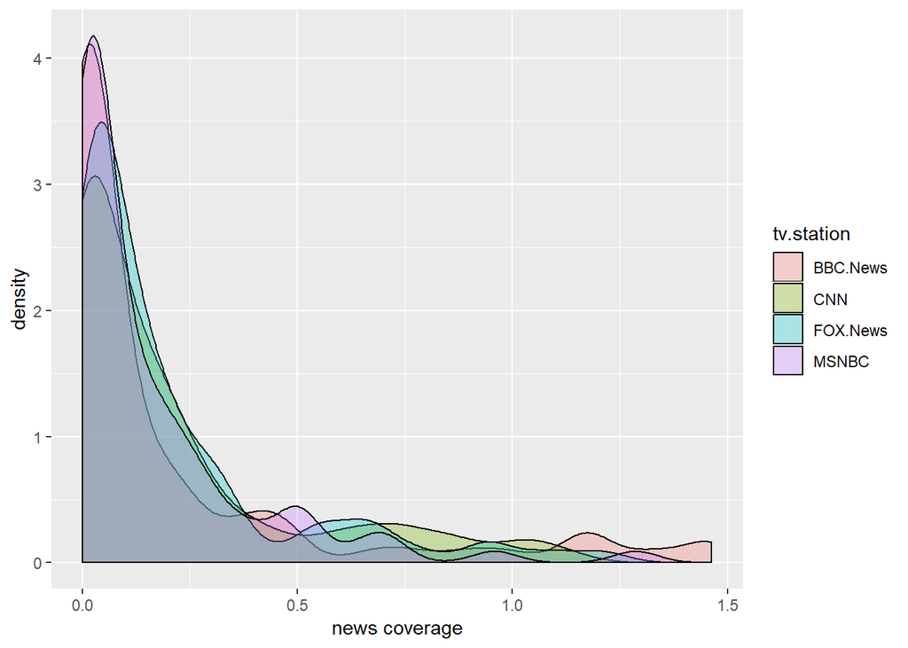

```r
#create density plots
ggplot(data = plot_df) +
  geom_density(aes(x = coverage, fill = tv.station), alpha = 0.3) +
  xlab("news coverage")  #label the x axis
```

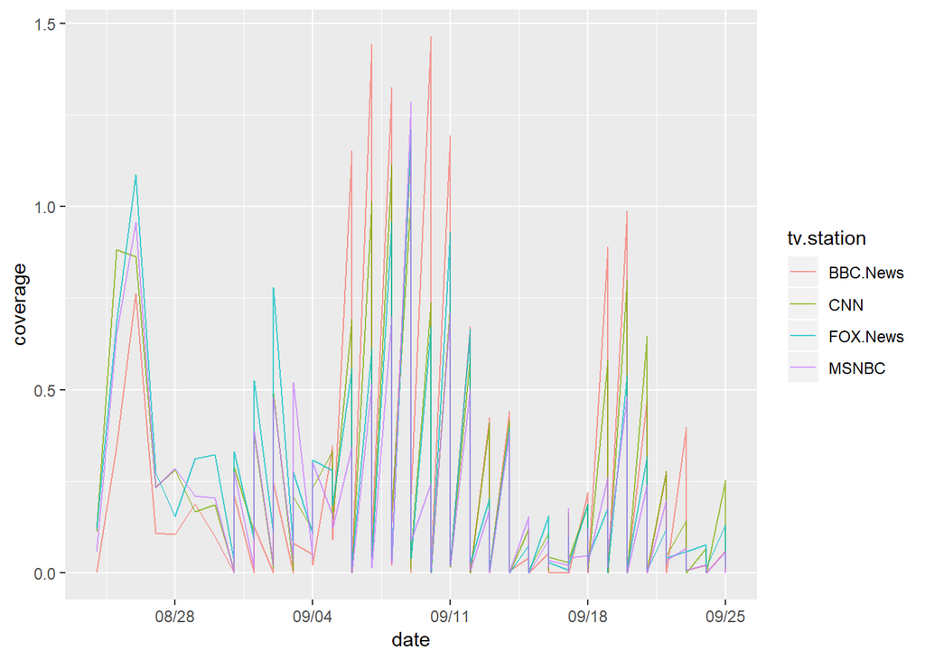

```r
#create a timeseries of news coverage
ggplot(data = plot_df) +
  geom_line(aes(x = as.Date(Date, "%m/%d/%y"), y = coverage,
                group = tv.station,
                color = tv.station), alpha = 0.7) +
  xlab("date") +
  scale_x_date(labels = date_format("%m/%d"),
               breaks = date_breaks("1 week"))
```

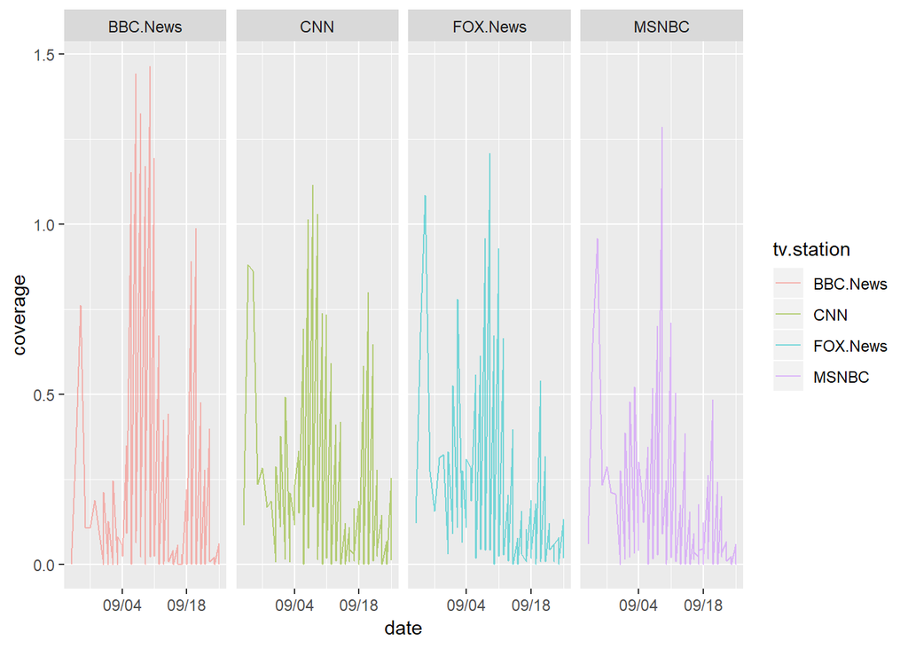

```r
#we could also have separate plots by tv station by using facet_wrap()
ggplot(data = plot_df) +
  geom_line(aes(x = as.Date(Date, "%m/%d/%y"), y = coverage,
                group = tv.station,
                color = tv.station), alpha = 0.5) +
  facet_wrap(~tv.station, ncol = 4) +
  xlab("date") +
  scale_x_date(labels = date_format("%m/%d"),
               breaks = date_breaks("2 weeks"))
```

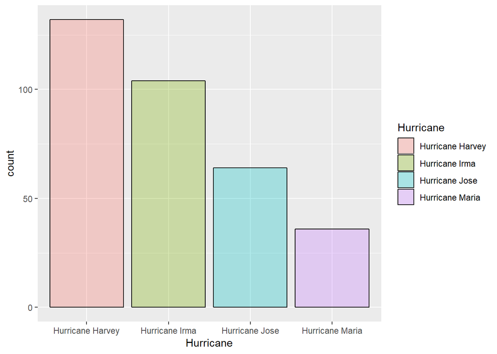

```r
#create histograms of each hurricane in terms of number of observations
ggplot(data = plot_df) +
  geom_bar(aes(x = Hurricane, fill = Hurricane),
           color = "black",
           stat = "count", #calculates the number of cases in each group
           alpha = 0.3)
```

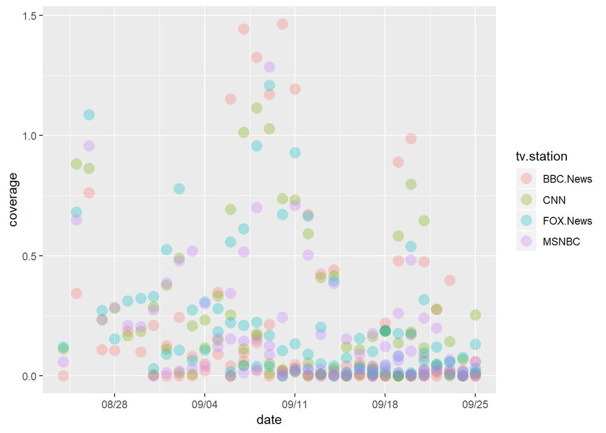

```r
#create scatterplot of news coverage against time by TV Station
ggplot(data = plot_df) +
  geom_point(aes(y = coverage, x = as.Date(Date, "%m/%d/%y"), color = tv.station),
             shape = 16,
             size = 4,
             alpha = 0.3) +
  xlab("date") +
  scale_x_date(labels = date_format("%m/%d"),
               breaks = date_breaks("1 week"))
```

You may need to overlay plots sometimes, you can do this via layers, remember that they need to share common x and y axes.

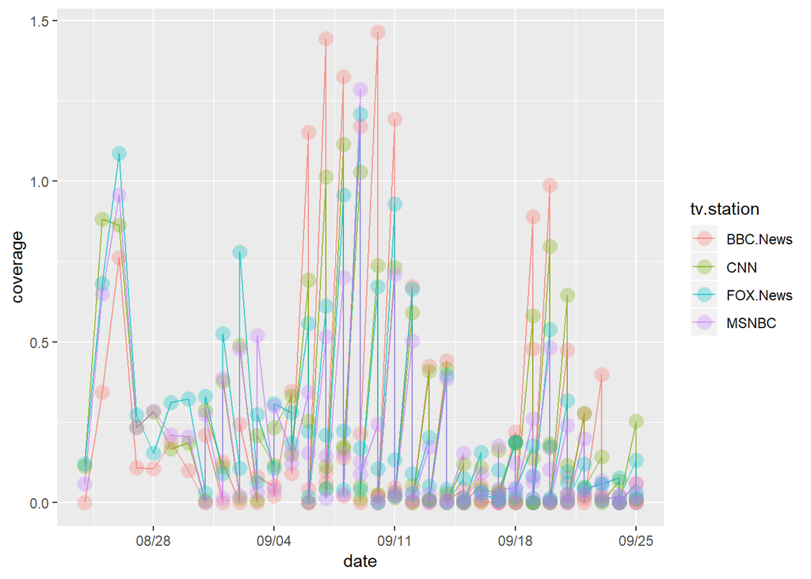

```r
#overlay scatterplot on timeseries lineplot
ggplot(data = plot_df) +
  geom_line(aes(x = as.Date(Date, "%m/%d/%y"), y = coverage,
                group = tv.station,
                color = tv.station), alpha = 0.7) +
  geom_point(aes(y = coverage, x = as.Date(Date, "%m/%d/%y"), color = tv.station),
             shape = 16,
             size = 4,
             alpha = 0.3) +
  xlab("date") +
  scale_x_date(labels = date_format("%m/%d"),
               breaks = date_breaks("1 week"))
```

## 8. Fitting Linear Models

Assuming in a bizarre world, we want to find out if MSNBC media coverage has an effect on CNN media coverage

```r
#regress CNN on MSNBC
model <- lm(CNN ~ MSNBC, data = df)
summary(model)
```

```
##
## Call:
## lm(formula = CNN ~ MSNBC, data = df)
##
## Residuals:
##      Min       1Q   Median       3Q      Max
## -0.37763 -0.05024 -0.03261  0.01998  0.44140
##
## Coefficients:
##             Estimate Std. Error t value Pr(>|t|)
## (Intercept)  0.03744    0.01753   2.136   0.0357 *
## MSNBC        1.05631    0.06268  16.851   <2e-16 ***
## ---
## Signif. codes:  0 '***' 0.001 '**' 0.01 '*' 0.05 '.' 0.1 ' ' 1
##
## Residual standard error: 0.133 on 82 degrees of freedom
## Multiple R-squared:  0.7759, Adjusted R-squared:  0.7732
## F-statistic:   284 on 1 and 82 DF,  p-value: < 2.2e-16
```

Assuming we’d like to run another model that adds hurricane fixed effects

```r
library(lfe)
model2 <- felm(CNN ~ MSNBC | as.factor(Hurricane), data = df)
summary(model2)
```

```
##
## Call:
##    felm(formula = CNN ~ MSNBC | as.factor(Hurricane), data = df)
##
## Residuals:
##      Min       1Q   Median       3Q      Max
## -0.37567 -0.06381 -0.00354  0.02036  0.39777
##
## Coefficients:
##       Estimate Std. Error t value Pr(>|t|)
## MSNBC  1.02211    0.05931   17.23   <2e-16 ***
## ---
## Signif. codes:  0 '***' 0.001 '**' 0.01 '*' 0.05 '.' 0.1 ' ' 1
##
## Residual standard error: 0.1196 on 79 degrees of freedom
## Multiple R-squared(full model): 0.8253   Adjusted R-squared: 0.8164
## Multiple R-squared(proj model): 0.7899   Adjusted R-squared: 0.7793
## F-statistic(full model):93.29 on 4 and 79 DF, p-value: < 2.2e-16
## F-statistic(proj model):   297 on 1 and 79 DF, p-value: < 2.2e-16
```

#### More Helpful Links

- https://github.com/yixinsun1216/covertoperations_manual/wiki/R-Guide
- https://tutorials.iq.harvard.edu/R/Rstatistics/Rstatistics.html
- http://genomicsclass.github.io/book/pages/dplyr_tutorial.html
- https://cran.r-project.org/web/packages/dplyr/vignettes/dplyr.html
- https://tutorials.iq.harvard.edu/R/Rgraphics/Rgraphics.html